# Análise espacial da criminalidade em uma grande metrópole: um estudo de caso para o município de São Paulo

Raul de Sá Durlo

21 de julho de 2017

## 1. Introdução

Os índices de criminalidade verificada em um bairro de São Paulo se associam aos mesmos índices verificados nos demais bairros? Existe variação sistemática na ocorrência de crimes entre os bairros de São Paulo? O tipo do uso do solo urbano, a composição de emprego, renda domiciliar e estrutura populacional afetam o crime nos bairros de São Paulo de que forma? Essas são as perguntas que nortearam o trabalho aqui desenvolvido.

Portanto, este trabalho tem como objetivo analisar a criminalidade em uma grande metrópole mundial. O município analisado é o de São Paulo, no Brasil, em dois períodos diferentes (anos 2000 e 2010), de onde foram extraídas informações de ocorrências de crime e de características socioeconômicas disponíveis para nível de distritos (bairros). A utilização do município de São Paulo se deve ao fato de esta ser a maior metrópole da América Latina.

Os crimes analisados são: homicídios, roubo e furto de veículos, normalizados por 100000 habitantes em cada unidade territorial. O problema é que as estatísticas criminais são agregadas entre 93 distritos policiais, enquanto as demais estatísticas socioeconômicas são agregadas por distritos municipais. O procedimento empírico foi, portanto, realizado tratando as diferenças entre distritos policiais e distritos municipais com uma metodologia de compatibilização entre as unidades geográficas que apresentaram diferenças em seus limites de território.

Já como metodologia de análise, foi proposto o teste de não-aleatoriedade espacial das taxas de criminalidade em SP, através da estatística *I de Moran* calculada para as modalidades de crime supracitadas. Os resultados evidenciam a persistência da autocorrelação positiva das taxas de crime e a análise dos *diagramas de dispersão de Moran* indicam uma forte influência do chamado “centro velho” na concentração de crimes. De outro lado, bairros de classe média e alta, próximos ou dentro do centro expandido da cidade, se caracterizam como “bolsões de segurança”.

Outra análise proposta é a estimação de um modelo espacial dos determinantes da criminalidade por meio da metodologia de Regressões Aparentemente não-Relacionadas (SUR-espacial). O efeito espacial específico do SUR-espacial se refere à presença de correlação nos termos de erro das equações do sistema, o que segundo Anselin (1988) pode ser entendida como uma forma de autocorrelação espacial, uma vez que seus parâmetros variam somente em relação ao espaço e não aos períodos analisados. Este trabalho explora tais características do modelo SUR em conjunto com os efeitos de vizinhança (matriz W) no início e no final da década de 2000 (anos 200 e 2010).

De um modo geral, os resultados do modelo SUR-espacial corroboram com o argumento de que as características da cidade são importantes nos padrões espaço-temporais da criminalidade, que por sua vez diferem de acordo com a modalidade de crime analisada. É possível ainda argumentar que o crime em uma grande cidade é um fenômeno complexo, determinados por características de ambiente social específicas.

## 2. Revisão bibliográfica

A década de 2000 é abordada com frequência no debate sobre segurança pública em São Paulo em razão da queda persistente das taxas de crime no em todo território estadual(Manso, Mello, Cerqueira). No gráfico 1, é possível observar que no início da década as taxas de homicídio eram particularmente altas na capital paulista, seguido de um padrão semelhante em seu entorno (Região Metropolitana de São paulo). Ao final da década de 2000, todavia, a cidade de São Paulo apresenta taxa de homicídio menores que sua Região Metropolitana e muito próximo do valor verificado para os demais municípios da região (cerca de 10 homicídios por 100000 habitantes).

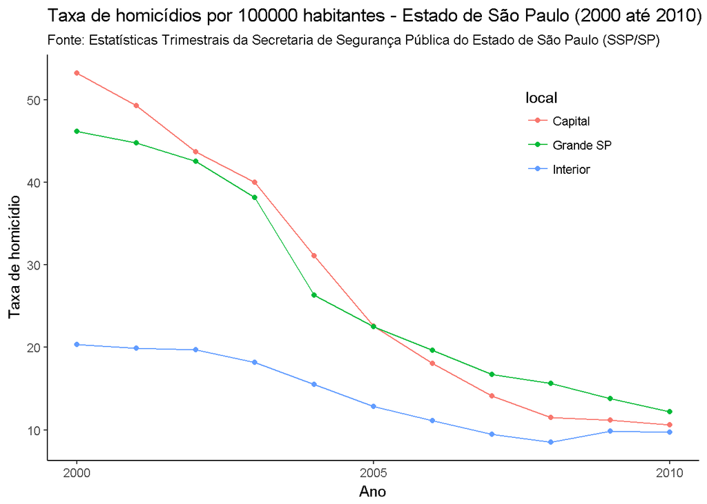

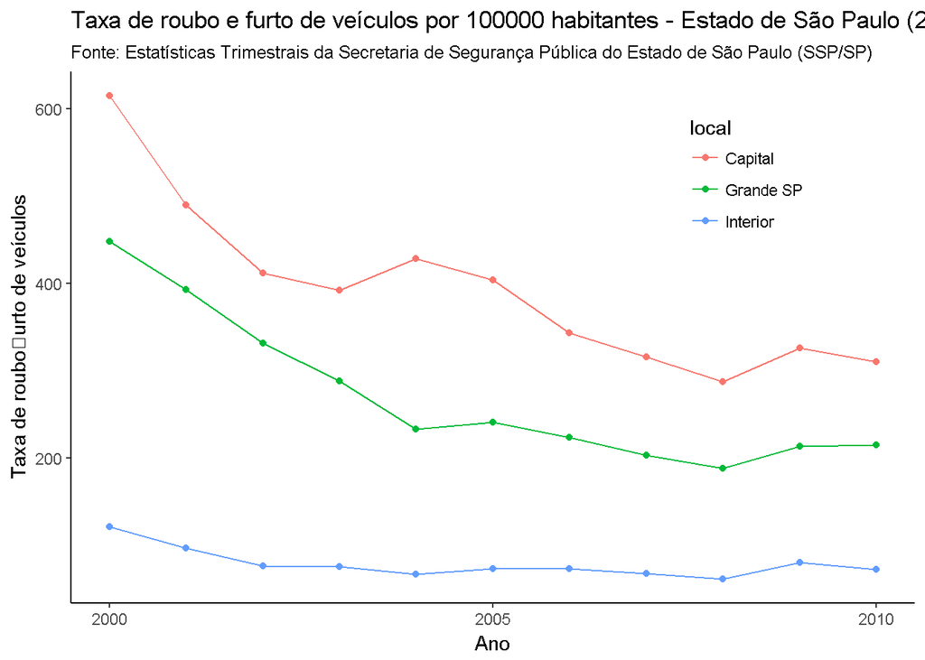